# Group Assignment Instructions

Pieter Schoonees

November 2021

# Problem description

You are interested in investing in peer-to-peer loans on an online platform based in the USA. In order to calculate an expected return on your investment, you want to take into account the probability that a loan will default. Your goal in this assignment is to find the best possible model for predicting loan default, a binary outcome in the `loan_status` variable. This prediction should be made before a loan is issued. You should therefore, as far as is possible, make sure that you use only information available to investors before a loan is issued.

Make sure you define your goals for the model carefully beforehand, set expectations in terms of relevant metrics, and plan your model assessment steps. Consider various types of algorithms in your modelling effort, and take care to improve upon your initial efforts by learning more about the problem and data as you complete iterations of the modelling process.

# Data

The data is available in three parts:

1. The training data in `loans_train.csv` contain approx. 140 000 labelled loans
2. The test data in `loans_test.csv` contain approx. 94 000 unlabelled loans
3. The test labels in `loans_test_labels.csv` contain the labels for the test data (in the same order)

You are supplied with (1) and (2). The labels in (3) will only be made available at a later stage. The test data should be used for assessing your favoured solution, after using the training data to develop this solution.

The data is imbalanced. The data is also large. You are encouraged to be pragmatic by taking subsamples in the initial stages of the project to allow you to iterate faster. A small part of this data have already been used in some tutorials in the course.

## Data description

The variables are as follows:

| Variable Name | Variable Description |
| --- | --- |
| `id` | Loan ID |
| `loan_amnt` | The total principal amount of the loan (in USD) |
| `funded_amnt` | Amount for which the loan was issued (in USD) |
| `int_rate` | The interest rate of the loan as a percentage |
| `grade` | The quality of the loan (determined by the platform) |
| `home_ownership` | Borrower’s home status (i.e. mortgage, rent) |
| `emp_length` | Borrower’s length of employment |
| `annual_inc` | Borrower’s reported annual income (in USD) |
| `verification_status` | The verification of the borrower’s information |
| `loan_status` | The final status of the loan (the prediction target) |
| `dti` | The debt-to-income ratio of the borrower (amount of debt divided by annual income) |
| `delinq_2yrs` | The number of times the borrower had been 30+ days past due on a payment in the past 2 years |
| `open_acc` | Number of open credit lines on the borrower’s credit file |
| `pub_rec` | The borrower’s number of derogatory public records (i.e. bankruptcy filings, tax liens, judgments, etc.) |
| `fico_range_low` | Lower range of FICO credit score |
| `fico_range_high` | Upper range of FICO credit score |
| `total_paymnt` | Total amount repaid on loan |
| `recoveries` | Amount recovered in case the payments weren’t made according to the original plan |
| `funded_amnt_inv` | The total amount committed by investors for that loan at that point in time |
| `installment` | The monthly payment owed by the borrower if the loan is issued |
| `sub_grade` | Sub-classification of the quality of the loan (determined by the platform) |
| `emp_title` | The job title supplied by the borrower when applying for the loan |
| `purpose` | A category provided by the borrower for the loan request |
| `title` | The loan title provided by the borrower |
| `addr_state` | The state provided by the borrower in the loan application |
| `zip_code` | The first 3 numbers of the zip code provided by the borrower in the loan application |
| `earliest_cr_line_year` | Year of date when the borrower first took on credit |
| `earliest_cr_line_year` | Month of date when the borrower first took on credit |

# Background

As a young professional, it is important to use your money wisely. Finding ways to make your money grow passively is therefore of great value. You could, for example, invest your hard-earned savings in corporate stocks, government bonds, exchange-traded funds or real estate. Besides these widely known asset classes, the founding of peer-to-peer lending platforms has made it possible to invest in other people through P2P lending.

P2P lending is facilitated by a platform where investors lend to individuals who need money. Borrower needs range from paying off a loan to seeking funding for a business. The interest earned by lenders is based on an abundance of information about the borrower, such as credit score, employment status, annual income, debt-to-income ratio and number of open credit lines. Lenders can often earn a higher return on peer-to-peer loans than they can on savings and other investment products. However, with higher return comes higher risk. There exists a chance that the borrower will default on his or her loan.

## The platform

Each loan is split into “notes” of $25 dollars each. Investors can choose to invest in one or more notes. A loan of $2,000 would be split into 80 notes, each of which can be held by a different investor. Loans are selected by investors based on the data available on the platform.

Below is a screenshot illustrating what an overview of some loans typically looks like on the platform:

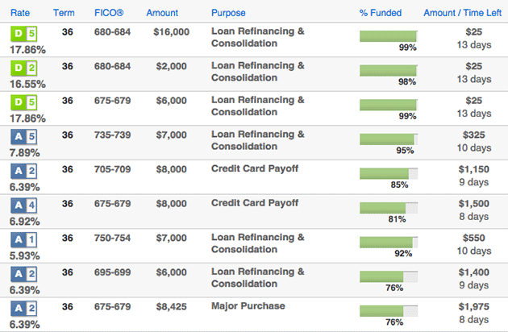

A loan is only funded when all the notes are invested in. There are rare exceptions when the borrower accepts a loan for a smaller amount, but this occurs infrequently.

When clicking on a loan, more information is available. Here is an example:

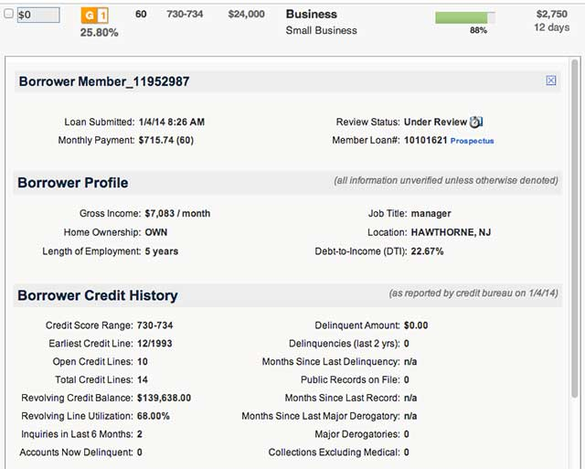

The definition of loan status is very important for our modelling purposes. A loan that has been repaid in full is labeled *Fully Paid*. A *Current* loan is one that is still being paid back according to the repayment schedule. A *Late* loan is a loan where payment is 16 to 120 days behind schedule. If the payment is 121 to 150 days late, it is considered to be in *Default*. If the platform does not think the loan will be paid back, it is given a *Charged-Off* status. This happens to loans labeled as in *Default* after 150 days.

The situation for loan status is therefore as follows:

| Number of days past due date | Loan status |
| --- | --- |
| 0 | Current |
| 16-120 | Late |
| 121-150 | Default |
| 150+ | Charged-Off |

Hence five months after the due date, all loans are either fully paid or charged-off. We will refer to these as fully paid versus default. This is the target variable we want to predict for the case, which we describe next.

All loans in the supplied data set are for 36 months, and have reached either *Fully Paid* or *Charged Off* status.

# Instructions

You are expected to:

- Clearly define the metrics you are interested in and the values of these that you want to achieve. These should be documented upfront before you start your modelling process. Use multiple metrics.
- Perform an exploratory data analysis to gain a deeper understanding of the data, and to identify feature engineering steps that you may want to investigate for improving your models’ performance.
- Complete at least two rounds of modelling, where the first round may explore an initial set of models you are interested in, and where in the second round you take steps to improve on at least two of the most promising solutions from your first iteration.
- Use a well-defined model assessment setup which allows you to make decisions based on valid estimates of generalization performance.
- Use a variety of models from the course. The goal is to find the best solution from among the methods covered in the course. You do not have to try all methods, but at least four different types of methods should be considered. You are required to include at least one ensemble method in your consideration set.
- Assess the performance of your preferred model on the test set, when this becomes available, and compare this to your results from before.
- Document, in the form of annotated R code, your work in a reproducible fashion. All the results (tables, plots, and so forth) which you report should be able to be reproduced from these. Ideally, these are R notebooks or another form of an R Markdown document.
- Deliver your results in a recorded presentation, where all students in your group take part in the presentation. More details are given below.

# Presentation of results

Each team should provide:

1. a recorded presentation of no more than six minutes, discussing your results and giving your recommendations and insights, and
2. a collection of R notebooks (or similar documents) reproducing all results discussed in your presentation.

The presentation should introduce the problem and your goal(s). The data should be presented, and, optionally, interesting findings from your exploratory data analysis included. Next, provide an overview of your modelling approach. Explain intuitively for a non-technical audience how each of the methods you will report on works. Then present your results and insights, the recommendations for further steps, and the limitations of your approach. Make sure you include a table comparing different evaluation metrics of each model.

Your presentation should be understandable to non-expert peers. Avoid technical terminology; explain all terms which you use in an intuitive manner. All group members should participate in the video. You can upload the videos into the assignment folder available under the *Panopto Video* tab on Canvas (click the assignment folder icon in the top left of the folder which opens when you click on this tab).